# Introduction to R Problem Set

## 4

Make a scatter plot of `hwy` vs. `cyl`.

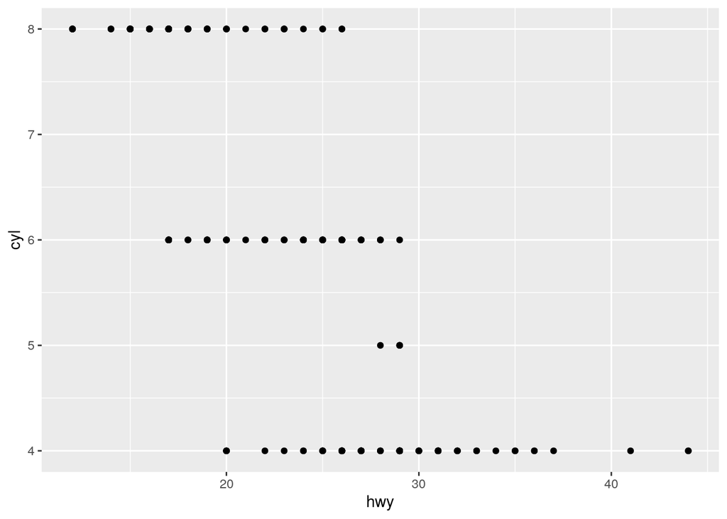

```r
ggplot(mpg, aes(x=hwy, y=cyl)) +
  geom_point()
```

## 5

What happens if you make a scatter plot of `class` vs `drv`? Why is the plot not useful?

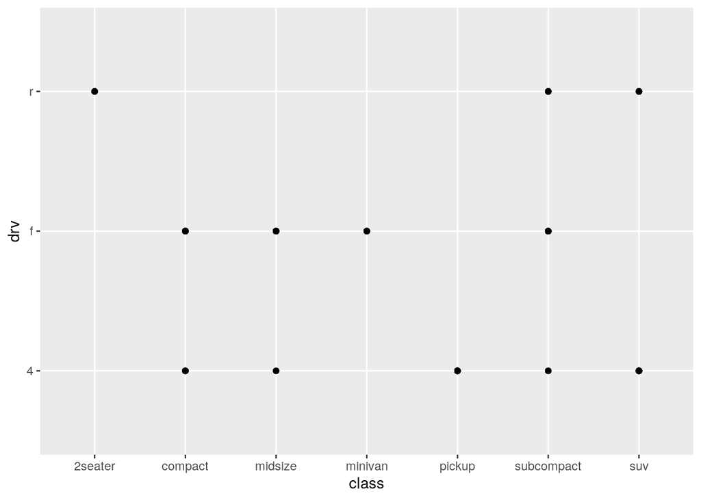

```r
ggplot(mpg, aes(x=class, y=drv)) +
  geom_point()
```

```r
# class and drv are both unordered categorical variables, so "increasing"
# values on the x and y axes have no meaning. Additionally, there are many
# points plotted on top of each other, so you don't know how many points
# are plotted for each pair of values.
```

# 3.3 Exercises

Complete all exercises for this section.

## 1

What’s gone wrong with this code? Why are the points not blue? `ggplot(data = mpg) + geom_point(mapping = aes(x = displ, y = hwy, color = "blue"))`

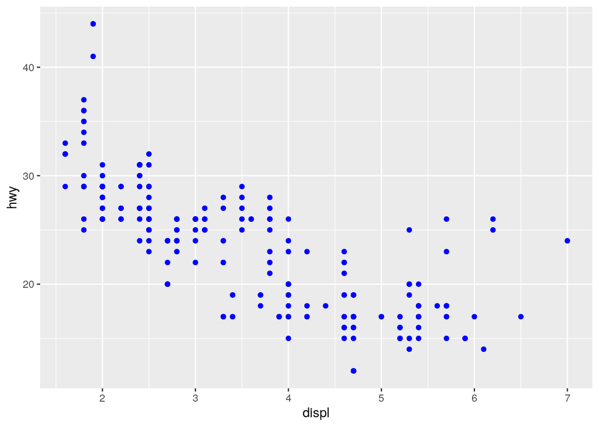

```r
ggplot(data = mpg) +
  geom_point(mapping = aes(x = displ, y = hwy), color = "blue")
```

```r
# color = "blue" needs to be outside of the aesthetic call. Using
# color inside the aesthetic mapping assigns colors based on a third variable.
```

## 2

Which variables in mpg are categorical? Which variables are continuous? (Hint: type `?mpg` to read the documentation for the dataset). How can you see this information when you run `mpg`?

```r
str(mpg)
```

```
## tibble [234 × 11] (S3: tbl_df/tbl/data.frame)
##  $ manufacturer: chr [1:234] "audi" "audi" "audi" "audi" ...
##  $ model       : chr [1:234] "a4" "a4" "a4" "a4" ...
##  $ displ       : num [1:234] 1.8 1.8 2 2 2.8 2.8 3.1 1.8 1.8 2 ...
##  $ year        : int [1:234] 1999 1999 2008 2008 1999 1999 2008 1999 1999 2008 ...
##  $ cyl         : int [1:234] 4 4 4 4 6 6 6 4 4 4 ...
##  $ trans       : chr [1:234] "auto(l5)" "manual(m5)" "manual(m6)" "auto(av)" ...
##  $ drv         : chr [1:234] "f" "f" "f" "f" ...
##  $ cty         : int [1:234] 18 21 20 21 16 18 18 18 16 20 ...
##  $ hwy         : int [1:234] 29 29 31 30 26 26 27 26 25 28 ...
##  $ fl          : chr [1:234] "p" "p" "p" "p" ...
##  $ class       : chr [1:234] "compact" "compact" "compact" "compact" ...
```

```r
# continuous: displ
# integer: year, cyl, cty, hwy
# categorical: the rest of the variables

# or
# head(mpg)
```

## 3

Map a continuous variable to color, size, and shape. How do these aesthetics behave differently for categorical vs. continuous variables?

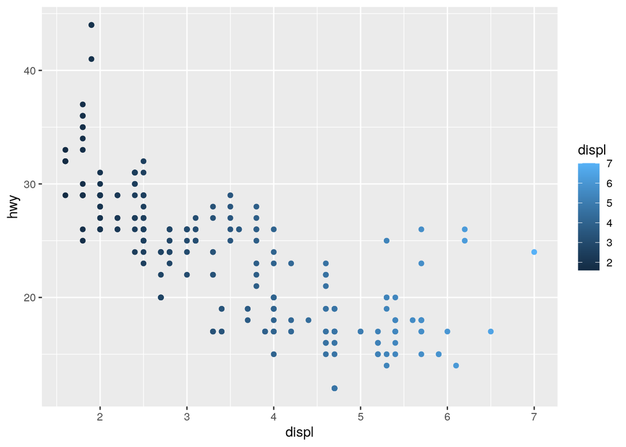

```r
ggplot(data = mpg) +
  geom_point(mapping = aes(x = displ, y = hwy, color = displ))
```

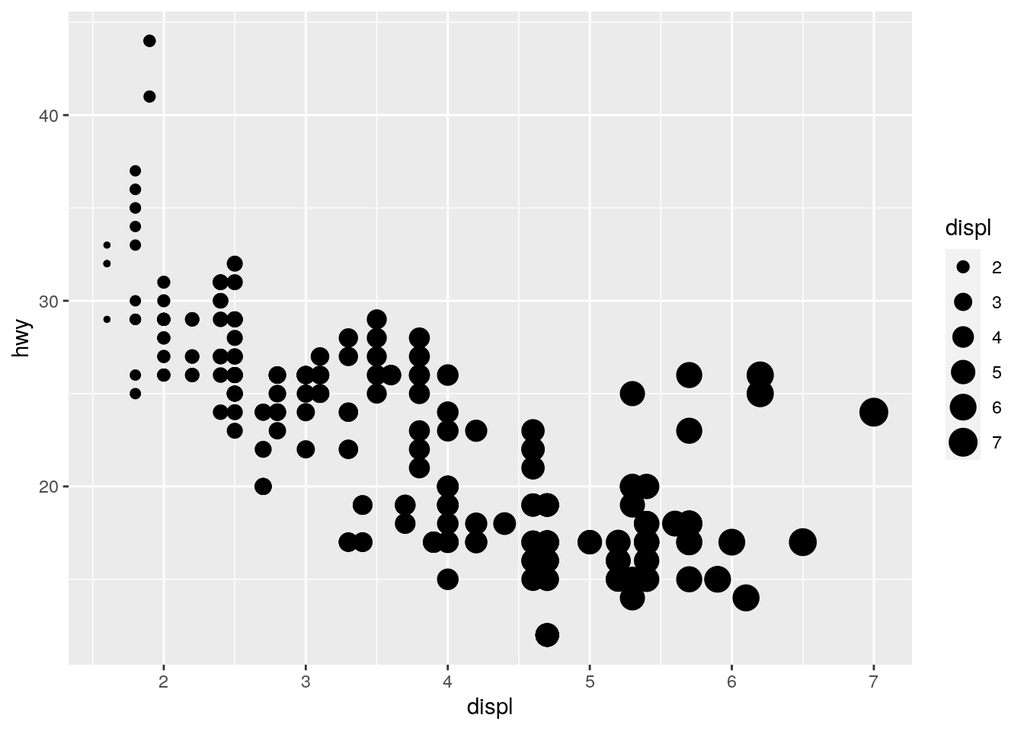

```r
ggplot(data = mpg) +
  geom_point(mapping = aes(x = displ, y = hwy, size = displ))
```

```r
# not run
#ggplot(data = mpg) +
#  geom_point(mapping = aes(x = displ, y = hwy, shape = displ))
# Error: A continuous variable can not be mapped to shape
```

## 4

What happens if you map the same variable to multiple aesthetics?

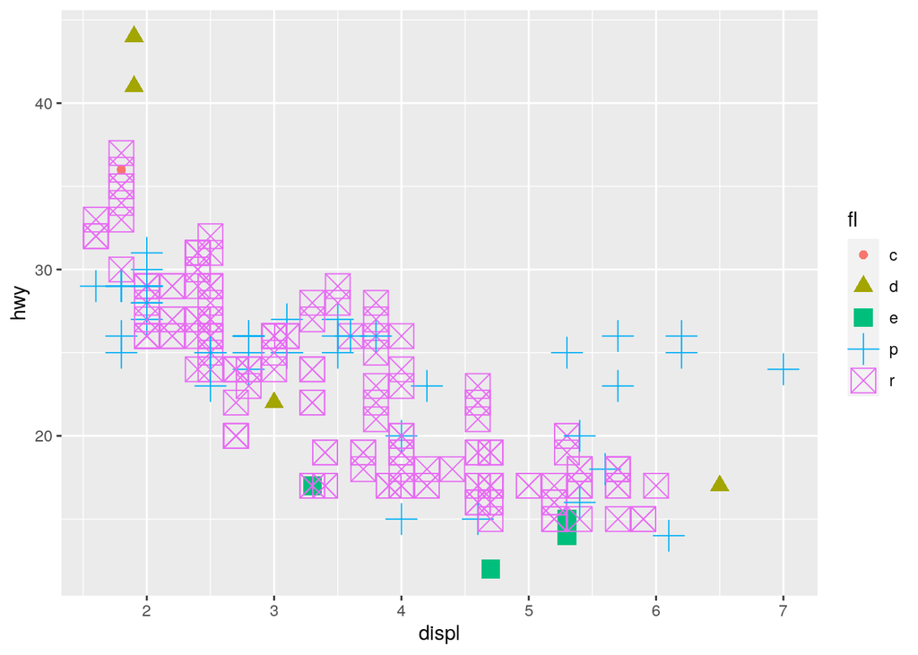

```r
ggplot(data = mpg) +
  geom_point(mapping = aes(x = displ, y = hwy, color = fl, size = fl, shape = fl))
```

```r
# Using the same variable doesn't add dimensions to the plot.
# It repeats the same information.
```

## 5

What does the stroke aesthetic do? What shapes does it work with? (Hint: use `?geom_point`)

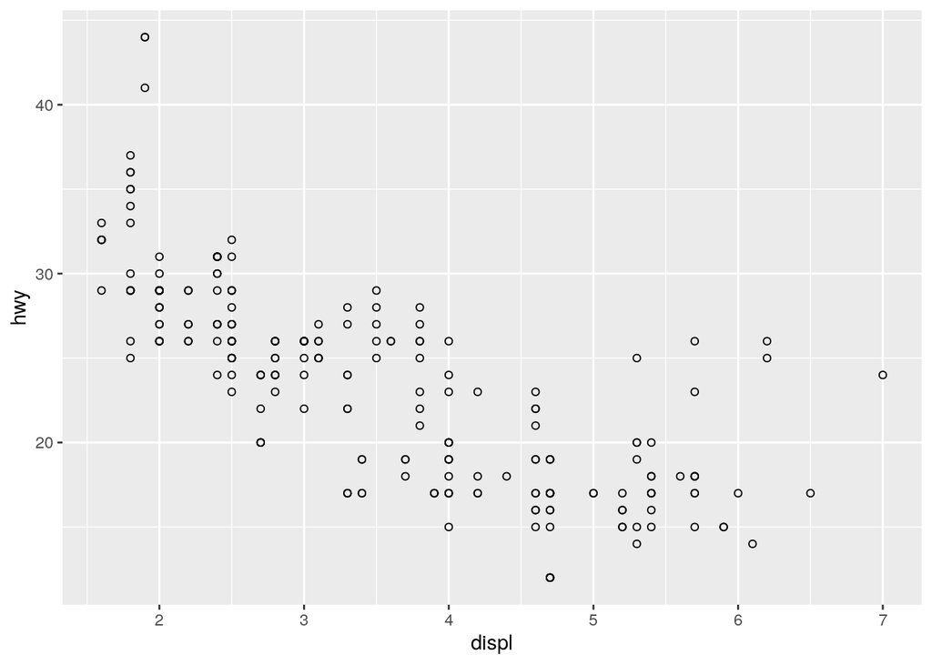

```r
ggplot(data = mpg) +
  geom_point(mapping = aes(x = displ, y = hwy), shape = 21, stroke = 0.5)
```

```r
# Works with shapes the have a border - it changes the thickness of the border.
```

## 6

What happens if you map an aesthetic to something other than a variable name, like `aes(colour = displ < 5)`? Note, you’ll also need to specify `x` and `y`.

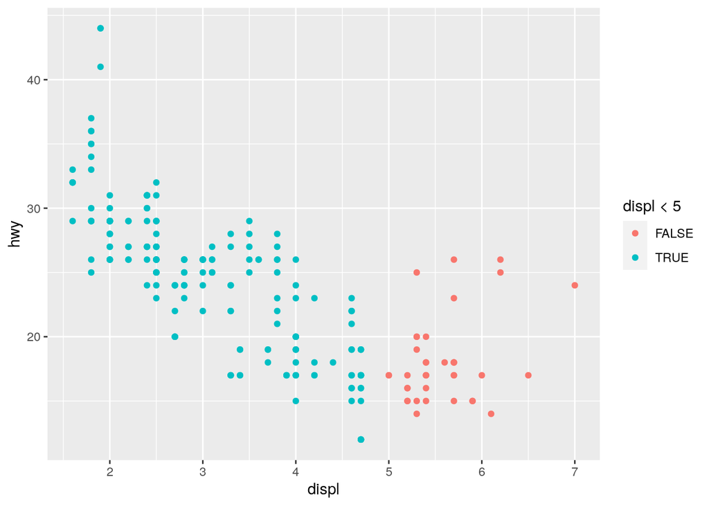

```r
ggplot(data = mpg) +
  geom_point(mapping = aes(x = displ, y = hwy, color = displ < 5))
```

# 3.4 Exercises

There are no exercises for this section.

# 3.5 Exercises

Complete exercises 1-4.

## 1

What happens if you facet on a continuous variable?

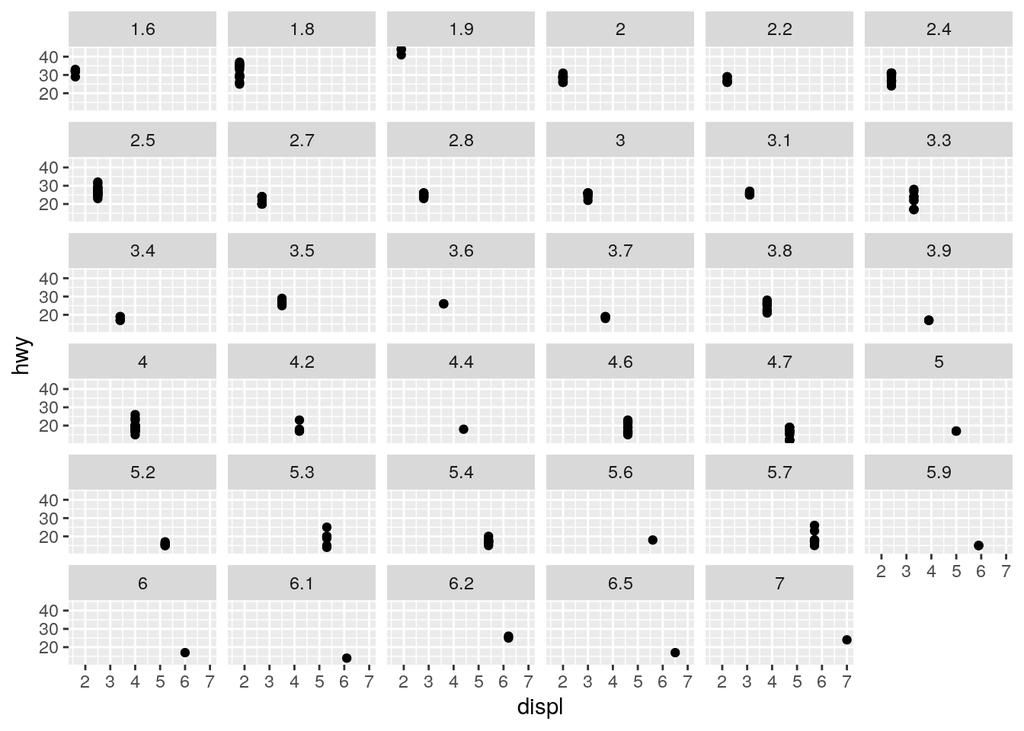

```r
ggplot(data = mpg) +
  geom_point(mapping = aes(x = displ, y = hwy)) +
  facet_wrap(~displ)
```

## 2

What do the empty cells in plot with `facet_grid(drv ~ cyl)` mean? How do they relate to this plot?

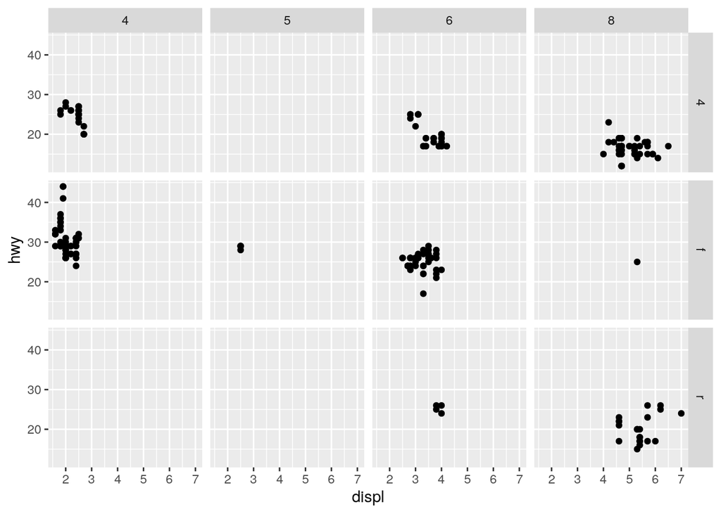

```r
ggplot(data = mpg) +
  geom_point(mapping = aes(x = displ, y = hwy)) +
  facet_grid(drv ~ cyl)
```

```r
# It means there are no x and y values associated with that combination
# of drv and cyl. For example, there are no cars in the dataset with 4WD
# and 5 cylinders.
```